# Modeling Variation of Cancer Mortality Rate in the United States

Group 1: Samantha Brown, Ruiyang Li, Jiyue Qin, Yi Xiao

12/16/2018

# Data Cleaning and Exploratory Analysis

## load data

```r
cancer_data <- read_csv("./data/Cancer_Registry.csv") %>%
        janitor::clean_names()
```

The Cancer Registry Dataset cantains information on cancer mortality rate across 3047 US counties. There are 34 variables which provide information on death rate and related demographical characteristics in each county. The outcome variable in this datset is `target_death rate` (continuous).

## tidy data

```r
# get numeric variables

num_var <- cancer_data %>%
       dplyr::select(-c(binned_inc, geography))

# summary table for all numberical variables:

num_var %>% skimr::skim_to_wide()%>% knitr::kable(digits = 3) %>% kableExtra::kable_styling(full_width = T, position = "left")
```

| type | variable | missing | complete | n | mean | sd | p0 | p25 | p50 | p75 | p100 | hist |
| --- | --- | --- | --- | --- | --- | --- | --- | --- | --- | --- | --- | --- |
| integer | avg_deaths_per_year | 0 | 3047 | 3047 | 185.97 | 504.13 | 3 | 28 | 61 | 149 | 14010 | ▇▁▁▁▁▁▁▁ |
| integer | med_income | 0 | 3047 | 3047 | 47063.28 | 12040.09 | 22640 | 38882.5 | 45207 | 52492 | 125635 | ▂▇▅▁▁▁▁▁ |
| integer | pop_est2015 | 0 | 3047 | 3047 | 1e+05 | 329059.22 | 827 | 11684 | 26643 | 68671 | 1e+07 | ▇▁▁▁▁▁▁▁ |
| numeric | avg_ann_count | 0 | 3047 | 3047 | 606.34 | 1416.36 | 6 | 76 | 171 | 518 | 38150 | ▇▁▁▁▁▁▁▁ |
| numeric | avg_household_size | 0 | 3047 | 3047 | 2.48 | 0.43 | 0.022 | 2.37 | 2.5 | 2.63 | 3.97 | ▁▁▁▁▇▇▁▁ |
| numeric | birth_rate | 0 | 3047 | 3047 | 5.64 | 1.99 | 0 | 4.52 | 5.38 | 6.49 | 21.33 | ▁▇▇▂▁▁▁▁ |
| numeric | incidence_rate | 0 | 3047 | 3047 | 448.27 | 54.56 | 201.3 | 420.3 | 453.55 | 480.85 | 1206.9 | ▁▇▇▁▁▁▁▁ |
| numeric | median_age | 0 | 3047 | 3047 | 45.27 | 45.3 | 22.3 | 37.7 | 41 | 44 | 624 | ▇▁▁▁▁▁▁▁ |
| numeric | median_age_female | 0 | 3047 | 3047 | 42.15 | 5.29 | 22.3 | 39.1 | 42.4 | 45.3 | 65.7 | ▁▁▃▇▅▁▁▁ |
| numeric | median_age_male | 0 | 3047 | 3047 | 39.57 | 5.23 | 22.4 | 36.35 | 39.6 | 42.5 | 64.7 | ▁▂▆▇▃▁▁▁ |
| numeric | pct_asian | 0 | 3047 | 3047 | 1.25 | 2.61 | 0 | 0.25 | 0.55 | 1.22 | 42.62 | ▇▁▁▁▁▁▁▁ |
| numeric | pct_bach_deg18_24 | 0 | 3047 | 3047 | 6.16 | 4.53 | 0 | 3.1 | 5.4 | 8.2 | 51.8 | ▇▅▁▁▁▁▁▁ |
| numeric | pct_bach_deg25_over | 0 | 3047 | 3047 | 13.28 | 5.39 | 2.5 | 9.4 | 12.3 | 16.1 | 42.2 | ▂▇▆▃▁▁▁▁ |
| numeric | pct_black | 0 | 3047 | 3047 | 9.11 | 14.53 | 0 | 0.62 | 2.25 | 10.51 | 85.95 | ▇▁▁▁▁▁▁▁ |
| numeric | pct_emp_priv_coverage | 0 | 3047 | 3047 | 41.2 | 9.45 | 13.5 | 34.5 | 41.1 | 47.7 | 70.7 | ▁▂▆▇▇▅▁▁ |
| numeric | pct_employed16_over | 152 | 2895 | 3047 | 54.15 | 8.32 | 17.6 | 48.6 | 54.5 | 60.3 | 80.1 | ▁▁▁▅▇▇▂▁ |
| numeric | pct_hs18_24 | 0 | 3047 | 3047 | 35 | 9.07 | 0 | 29.2 | 34.7 | 40.7 | 72.5 | ▁▁▃▇▆▂▁▁ |
| numeric | pct_hs25_over | 0 | 3047 | 3047 | 34.8 | 7.03 | 7.5 | 30.4 | 35.3 | 39.65 | 54.8 | ▁▁▂▅▇▆▂▁ |
| numeric | pct_married_households | 0 | 3047 | 3047 | 51.24 | 6.57 | 22.99 | 47.76 | 51.67 | 55.4 | 78.08 | ▁▁▂▆▇▂▁▁ |
| numeric | pct_no_hs18_24 | 0 | 3047 | 3047 | 18.22 | 8.09 | 0 | 12.8 | 17.1 | 22.7 | 64.1 | ▂▇▇▃▁▁▁▁ |
| numeric | pct_other_race | 0 | 3047 | 3047 | 1.98 | 3.52 | 0 | 0.3 | 0.83 | 2.18 | 41.93 | ▇▁▁▁▁▁▁▁ |
| numeric | pct_private_coverage | 0 | 3047 | 3047 | 64.35 | 10.65 | 22.3 | 57.2 | 65.1 | 72.1 | 92.3 | ▁▁▂▅▇▇▅▁ |
| numeric | pct_private_coverage_alone | 609 | 2438 | 3047 | 48.45 | 10.08 | 15.7 | 41 | 48.7 | 55.6 | 78.9 | ▁▁▅▇▇▅▂▁ |
| numeric | pct_public_coverage | 0 | 3047 | 3047 | 36.25 | 7.84 | 11.2 | 30.9 | 36.3 | 41.55 | 65.1 | ▁▂▅▇▇▃▁▁ |
| numeric | pct_public_coverage_alone | 0 | 3047 | 3047 | 19.24 | 6.11 | 2.6 | 14.85 | 18.8 | 23.1 | 46.6 | ▁▃▇▇▃▁▁▁ |
| numeric | pct_some_col18_24 | 2285 | 762 | 3047 | 40.98 | 11.12 | 7.1 | 34 | 40.4 | 46.4 | 79 | ▁▁▅▇▅▂▁▁ |
| numeric | pct_unemployed16_over | 0 | 3047 | 3047 | 7.85 | 3.45 | 0.4 | 5.5 | 7.6 | 9.7 | 29.4 | ▂▇▇▂▁▁▁▁ |
| numeric | pct_white | 0 | 3047 | 3047 | 83.65 | 16.38 | 10.2 | 77.3 | 90.06 | 95.45 | 100 | ▁▁▁▁▁▂▃▇ |
| numeric | percent_married | 0 | 3047 | 3047 | 51.77 | 6.9 | 23.1 | 47.75 | 52.4 | 56.4 | 72.5 | ▁▁▁▅▇▇▂▁ |
| numeric | poverty_percent | 0 | 3047 | 3047 | 16.88 | 6.41 | 3.2 | 12.15 | 15.9 | 20.4 | 47.4 | ▂▇▇▅▂▁▁▁ |
| numeric | study_per_cap | 0 | 3047 | 3047 | 155.4 | 529.63 | 0 | 0 | 0 | 83.65 | 9762.31 | ▇▁▁▁▁▁▁▁ |
| numeric | target_death_rate | 0 | 3047 | 3047 | 178.66 | 27.75 | 59.7 | 161.2 | 178.1 | 195.2 | 362.8 | ▁▁▆▇▂▁▁▁ |

```r
# 1. check missing data

## presence of large amount of missing data (over 5%)  in three variabls: pct_some_col18_24(75%), pct_private_coverage_alone(20%) and pct_employed16_over(5%)


cancer_data %>%
  summarise_all(funs(sum(is.na(.)))) %>%
  gather(term, na_num, avg_ann_count:birth_rate) %>%
  filter(na_num > 0) %>%
  arrange(desc(na_num)) %>%
  mutate(percent = round(na_num/sum(na_num), 2)) %>%
        knitr::kable(col.names = c("variable name",
                           "number of missing value",
                           "percent"
                           )) %>%
        kableExtra::kable_styling(position = "left")
```

| variable name | number of missing value | percent |
| --- | --- | --- |
| pct_some_col18_24 | 2285 | 0.75 |
| pct_private_coverage_alone | 609 | 0.20 |
| pct_employed16_over | 152 | 0.05 |

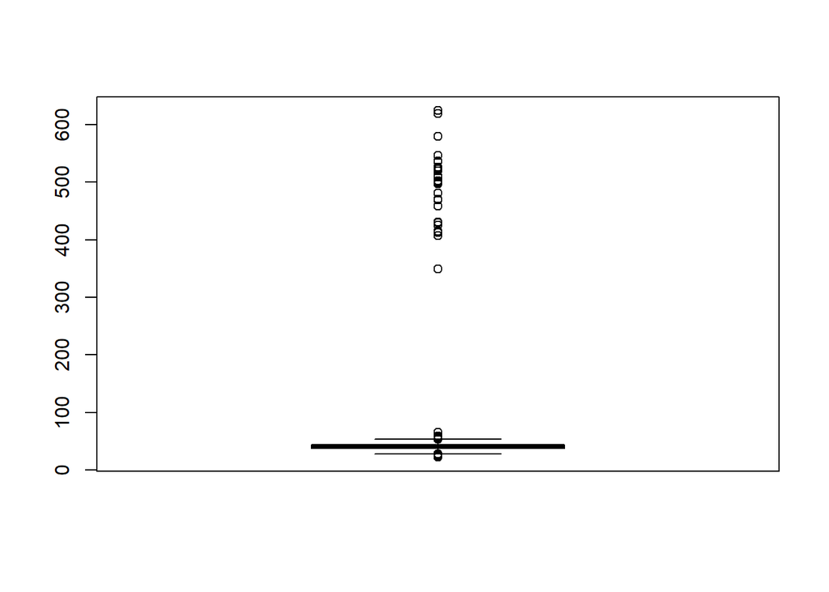

```r
# 2. check abnormal values

## median age bigger than 100 is abnormal

boxplot(cancer_data$median_age)
```

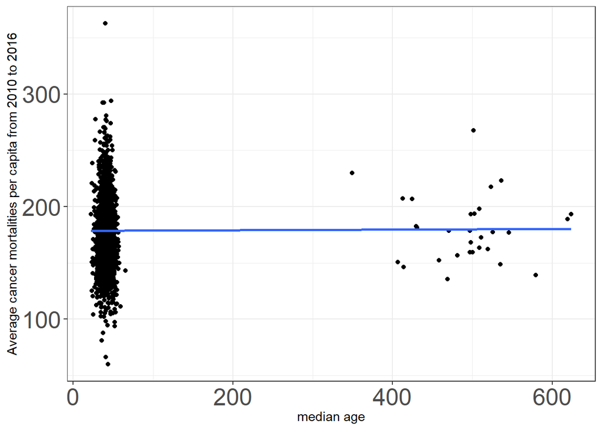

```r
# 3. look at linear relationship

## ralationship with median age

cancer_data %>%
  select(target_death_rate, median_age) %>%
  ggplot(aes(x = median_age, y = target_death_rate)) +
    geom_point(na.rm = TRUE) +
    geom_smooth(se = FALSE, method = "lm") +
        labs(x = "median age",
             y = "Average cancer mortalities per capita from 2010 to 2016") +
        theme_bw() +
        theme(axis.text=element_text(size=20))
```

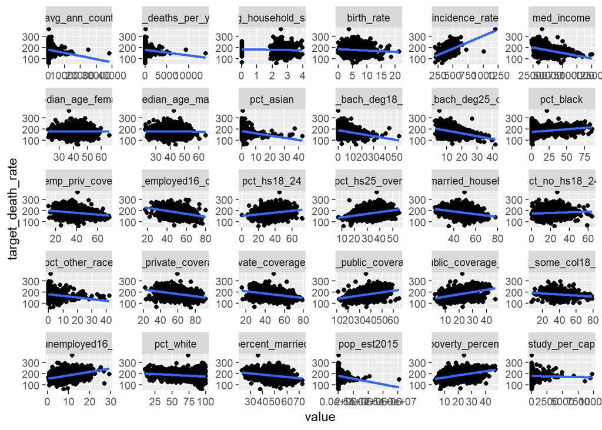

```r
## relationship with other continuous variables
num_var %>%
        select(-median_age) %>%
        select(target_death_rate, avg_ann_count:birth_rate) %>%
        gather(key = key, value, avg_ann_count:birth_rate) %>%
        ggplot(aes(x = value, y = target_death_rate)) +
        facet_wrap(~ key, scales = "free") +
        geom_point(na.rm = TRUE) +
        geom_smooth(se = FALSE, method = "lm")
```

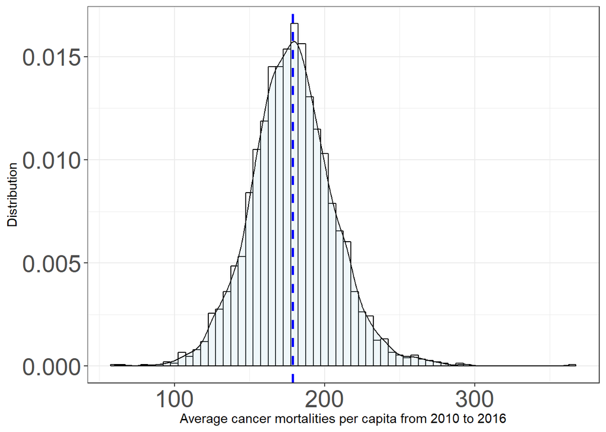

```r
# 4. check outcome distribution

# plot the histogram of the outcome: target death rate

cancer_data %>%
  ggplot(aes(x = target_death_rate)) +
    geom_histogram(aes(y = ..density..),
                   binwidth = 5, colour = "black", fill = "white") +
    geom_density(alpha = .2, fill = "lightblue") +
    geom_vline(aes(xintercept = mean(target_death_rate, na.rm = T)),
               color = "blue", linetype = "dashed", size = 1) +
        labs(x = "Average cancer mortalities per capita from 2010 to 2016",
             y = "Distribution") +
        theme_bw() +
        theme(axis.text=element_text(size=20))
```

Outcome variable target death rate has a normal distribution, which suggests linear regression could be an appropriate approach.

tidy procedures performed here: 1. eliminate the three variables with large amount of missing data

2. filter abnormal observations in `median_age`
3. reclassify the 4 race-related variables into `pct_black` and `pct_non_black`.
4. recategorize counties into four regions according to their geographical location including West, Midwest, Northeast and South.
5. discarded the categorical variable `binned_inc`

```r
tidy_data = cancer_data %>%
        separate(geography, into = c("county", "state"), sep = ", ") %>%
        mutate(region = case_when(
            state %in% c("Montana", "Arizona","Idaho","Colorado", "New Mexico","Utah","Nevada","Wyoming","Alaska","California",
            "Hawaii","Oregon","Washington") ~ "West",
            state %in% c("Illinois","Indiana", "Michigan","Iowa","Ohio", "Kansas","Minnesota","Missouri","Wisconsin", "Nebraska","North Dakota","South Dakota") ~ "Midwest",
            state %in% c("District of Columbia", "Delaware","Georgia",
            "Maryland", "North Carolina","Florida","South Carolina",
            "West Virginia","Kentucky", "Alabama","Virginia","Mississippi", "Arkansas","Tennessee","Louisiana","Oklahoma","Texas") ~ "South",
             state %in%  c("Connecticut","Maine","Massachusetts","New Hampshire",
             "Rhode Island","Vermont","New Jersey","New York",
             "Pennsylvania") ~ "Northeast" ), region = as.factor(region) %>% fct_relevel(., "West", "Midwest", "Northeast", "South")) %>%
        mutate(pct_non_black = pct_asian + pct_white + pct_other_race) %>%
        select(-pct_asian, -pct_white, -pct_other_race, -state, -county, -binned_inc, -pct_some_col18_24, -pct_employed16_over, -pct_private_coverage_alone) %>%
        filter(median_age < 100)
```

## intial variables selection

```r
# check collinearity
tidy_data %>% select(-region) %>% cor()
```

```
##                           avg_ann_count avg_deaths_per_year
## avg_ann_count               1.000000000          0.93965190
## avg_deaths_per_year         0.939651903          1.00000000
## target_death_rate          -0.142847096         -0.09042590
## incidence_rate              0.074173048          0.06308151
## med_income                  0.269259316          0.22345527
## pop_est2015                 0.927194608          0.97785766
## poverty_percent            -0.135408783         -0.06674789
## study_per_cap               0.081915427          0.06330445
## median_age                 -0.122427293         -0.14472138
## median_age_male            -0.124571396         -0.14784825
## median_age_female          -0.122300437         -0.14350898
## avg_household_size          0.064805243          0.08586030
## percent_married            -0.106759114         -0.18159021
## pct_no_hs18_24             -0.143798257         -0.13674564
## pct_hs18_24                -0.181583808         -0.15104700
## pct_bach_deg18_24           0.284580120          0.25986704
## pct_hs25_over              -0.311293537         -0.29615117
## pct_bach_deg25_over         0.320376154          0.29279415
## pct_unemployed16_over      -0.007313949          0.07112464
## pct_private_coverage        0.131899263          0.05590401
## pct_emp_priv_coverage       0.202169980          0.16012042
## pct_public_coverage        -0.172695935         -0.13115237
## pct_public_coverage_alone  -0.092871508         -0.02681725
## pct_black                   0.031061567          0.08419559
## pct_married_households     -0.107030746         -0.16128281
## birth_rate                 -0.034779860         -0.07398044
## pct_non_black              -0.023748551         -0.07437002
##                           target_death_rate incidence_rate    med_income
## avg_ann_count                  -0.142847096   0.0741730476  0.2692593157
## avg_deaths_per_year            -0.090425896   0.0630815140  0.2234552663
## target_death_rate               1.000000000   0.4483646499 -0.4278228970
## incidence_rate                  0.448364650   1.0000000000  0.0002616901
## med_income                     -0.427822897   0.0002616901  1.0000000000
## pop_est2015                    -0.119417938   0.0274866736  0.2354219521
## poverty_percent                 0.429309753   0.0080384738 -0.7882737413
## study_per_cap                  -0.022481663   0.0782398671  0.0444129716
## median_age                     -0.004288054  -0.0048412819 -0.1174798330
## median_age_male                -0.021415316  -0.0133254811 -0.0909595496
## median_age_female               0.012730774  -0.0078453440 -0.1529484097
```

[output cut: 281 more lines]

```
## percent_married             0.664537495
## pct_no_hs18_24             -0.170585991
## pct_hs18_24                -0.001015416
## pct_bach_deg18_24           0.130588175
## pct_hs25_over               0.059205349
## pct_bach_deg25_over         0.133270468
## pct_unemployed16_over      -0.522026711
## pct_private_coverage        0.441716811
## pct_emp_priv_coverage       0.315479999
## pct_public_coverage        -0.211655744
## pct_public_coverage_alone  -0.391072862
## pct_black                  -0.878375233
## pct_married_households      0.607894229
## birth_rate                 -0.005069686
## pct_non_black               1.000000000
```

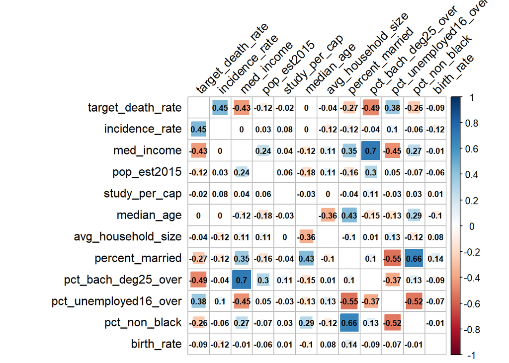

```r
# eliminate those variables with high correlations, 13 variables remainned
tidy_data = tidy_data %>%
        select(target_death_rate,incidence_rate, med_income, pop_est2015, study_per_cap, median_age, avg_household_size,percent_married, pct_bach_deg25_over, pct_unemployed16_over, pct_non_black, birth_rate, region)

# correlation plot
tidy_data %>% select(-region) %>%
        cor() %>%
        corrplot(method = "square", addCoef.col = "black", tl.col="black", tl.srt=45, insig = "blank", diag=FALSE, number.cex = .7)
```

```r
# descriptive statistics of selected variables
tidy_data %>% select(-region) %>% skimr::skim_to_wide()%>% knitr::kable(digits = 3) %>% kableExtra::kable_styling(full_width = T, position = "left")
```

| type | variable | missing | complete | n | mean | sd | p0 | p25 | p50 | p75 | p100 | hist |
| --- | --- | --- | --- | --- | --- | --- | --- | --- | --- | --- | --- | --- |
| integer | med_income | 0 | 3017 | 3017 | 47060.54 | 12053.19 | 22640 | 38887 | 45207 | 52476 | 125635 | ▂▇▅▁▁▁▁▁ |
| integer | pop_est2015 | 0 | 3017 | 3017 | 1e+05 | 330286.24 | 827 | 11703 | 26589 | 68502 | 1e+07 | ▇▁▁▁▁▁▁▁ |
| numeric | avg_household_size | 0 | 3017 | 3017 | 2.48 | 0.43 | 0.022 | 2.37 | 2.5 | 2.63 | 3.97 | ▁▁▁▁▇▇▁▁ |
| numeric | birth_rate | 0 | 3017 | 3017 | 5.64 | 1.98 | 0 | 4.52 | 5.38 | 6.49 | 21.33 | ▁▇▇▂▁▁▁▁ |
| numeric | incidence_rate | 0 | 3017 | 3017 | 448.15 | 54.61 | 201.3 | 420.3 | 453.55 | 480.8 | 1206.9 | ▁▇▇▁▁▁▁▁ |
| numeric | median_age | 0 | 3017 | 3017 | 40.82 | 5.2 | 22.3 | 37.7 | 40.9 | 43.8 | 65.3 | ▁▁▃▇▃▁▁▁ |
| numeric | pct_bach_deg25_over | 0 | 3017 | 3017 | 13.28 | 5.4 | 2.5 | 9.4 | 12.3 | 16.1 | 42.2 | ▂▇▆▃▁▁▁▁ |
| numeric | pct_non_black | 0 | 3017 | 3017 | 86.91 | 15.52 | 10.89 | 83.41 | 93.64 | 96.9 | 100 | ▁▁▁▁▁▁▂▇ |
| numeric | pct_unemployed16_over | 0 | 3017 | 3017 | 7.84 | 3.44 | 0.4 | 5.5 | 7.6 | 9.7 | 29.4 | ▂▇▇▂▁▁▁▁ |
| numeric | percent_married | 0 | 3017 | 3017 | 51.78 | 6.91 | 23.1 | 47.8 | 52.4 | 56.4 | 72.5 | ▁▁▁▅▇▇▂▁ |
| numeric | study_per_cap | 0 | 3017 | 3017 | 156.59 | 532.07 | 0 | 0 | 0 | 83.9 | 9762.31 | ▇▁▁▁▁▁▁▁ |
| numeric | target_death_rate | 0 | 3017 | 3017 | 178.65 | 27.74 | 59.7 | 161.3 | 178.1 | 195.2 | 362.8 | ▁▁▆▇▂▁▁▁ |

# model selection

## automatic approaches

### *backward elimination*

```r
mult.fit <- lm(target_death_rate ~ ., data = tidy_data)
summary(mult.fit)
```

```
##
## Call:
## lm(formula = target_death_rate ~ ., data = tidy_data)
##
## Residuals:
##      Min       1Q   Median       3Q      Max
## -122.815  -11.006   -0.448   10.668  131.939
##
## Coefficients:
##                         Estimate Std. Error t value Pr(>|t|)
## (Intercept)            1.189e+02  7.019e+00  16.938  < 2e-16 ***
## incidence_rate         2.014e-01  6.998e-03  28.779  < 2e-16 ***
## med_income            -1.802e-04  4.971e-05  -3.625 0.000294 ***
## pop_est2015           -1.503e-06  1.181e-06  -1.273 0.203233
## study_per_cap         -1.663e-04  6.873e-04  -0.242 0.808824
## median_age            -5.475e-02  8.880e-02  -0.617 0.537597
## avg_household_size     1.154e-01  9.287e-01   0.124 0.901120
## percent_married       -1.975e-01  9.124e-02  -2.164 0.030516 *
## pct_bach_deg25_over   -1.550e+00  1.028e-01 -15.076  < 2e-16 ***
## pct_unemployed16_over  1.021e+00  1.457e-01   7.010 2.94e-12 ***
## pct_non_black         -3.966e-02  3.461e-02  -1.146 0.251946
## birth_rate            -6.212e-01  1.935e-01  -3.210 0.001339 **
## regionMidwest          9.316e+00  1.230e+00   7.576 4.73e-14 ***
## regionNortheast        2.487e+00  1.791e+00   1.389 0.165012
## regionSouth            1.441e+01  1.216e+00  11.851  < 2e-16 ***
## ---
## Signif. codes:  0 '***' 0.001 '**' 0.01 '*' 0.05 '.' 0.1 ' ' 1
##
## Residual standard error: 19.66 on 3002 degrees of freedom
## Multiple R-squared:    0.5,  Adjusted R-squared:  0.4977
## F-statistic: 214.4 on 14 and 3002 DF,  p-value: < 2.2e-16
```

```r
# No study_per_cap
step1<-update(mult.fit, . ~ . - study_per_cap)
summary(step1)
```

```
##
## Call:
## lm(formula = target_death_rate ~ incidence_rate + med_income +
##     pop_est2015 + median_age + avg_household_size + percent_married +
##     pct_bach_deg25_over + pct_unemployed16_over + pct_non_black +
##     birth_rate + region, data = tidy_data)
##
## Residuals:
##      Min       1Q   Median       3Q      Max
## -122.666  -11.000   -0.451   10.678  131.967
##
## Coefficients:
##                         Estimate Std. Error t value Pr(>|t|)
## (Intercept)            1.189e+02  7.016e+00  16.952  < 2e-16 ***
## incidence_rate         2.012e-01  6.975e-03  28.854  < 2e-16 ***
## med_income            -1.798e-04  4.967e-05  -3.619   0.0003 ***
## pop_est2015           -1.509e-06  1.181e-06  -1.278   0.2013
## median_age            -5.495e-02  8.879e-02  -0.619   0.5360
## avg_household_size     1.105e-01  9.283e-01   0.119   0.9053
## percent_married       -1.961e-01  9.105e-02  -2.154   0.0313 *
## pct_bach_deg25_over   -1.552e+00  1.023e-01 -15.171  < 2e-16 ***
## pct_unemployed16_over  1.021e+00  1.457e-01   7.010 2.94e-12 ***
## pct_non_black         -4.003e-02  3.457e-02  -1.158   0.2470
## birth_rate            -6.226e-01  1.934e-01  -3.220   0.0013 **
## regionMidwest          9.296e+00  1.227e+00   7.578 4.64e-14 ***
## regionNortheast        2.491e+00  1.790e+00   1.392   0.1641
## regionSouth            1.441e+01  1.215e+00  11.858  < 2e-16 ***
## ---
## Signif. codes:  0 '***' 0.001 '**' 0.01 '*' 0.05 '.' 0.1 ' ' 1
##
## Residual standard error: 19.66 on 3003 degrees of freedom
## Multiple R-squared:    0.5,  Adjusted R-squared:  0.4978
## F-statistic:   231 on 13 and 3003 DF,  p-value: < 2.2e-16
```

```r
# No avg_household_size
step2<-update(step1, . ~ . - avg_household_size)
summary(step2)
```

```
##
## Call:
## lm(formula = target_death_rate ~ incidence_rate + med_income +
##     pop_est2015 + median_age + percent_married + pct_bach_deg25_over +
##     pct_unemployed16_over + pct_non_black + birth_rate + region,
##     data = tidy_data)
##
## Residuals:
##      Min       1Q   Median       3Q      Max
## -122.636  -10.987   -0.445   10.690  131.977
##
## Coefficients:
##                         Estimate Std. Error t value Pr(>|t|)
## (Intercept)            1.193e+02  6.214e+00  19.201  < 2e-16 ***
## incidence_rate         2.011e-01  6.920e-03  29.068  < 2e-16 ***
## med_income            -1.789e-04  4.911e-05  -3.643 0.000274 ***
## pop_est2015           -1.502e-06  1.179e-06  -1.274 0.202748
## median_age            -5.814e-02  8.463e-02  -0.687 0.492134
## percent_married       -1.954e-01  9.085e-02  -2.151 0.031556 *
## pct_bach_deg25_over   -1.554e+00  1.016e-01 -15.295  < 2e-16 ***
## pct_unemployed16_over  1.023e+00  1.447e-01   7.071 1.90e-12 ***
## pct_non_black         -4.011e-02  3.456e-02  -1.161 0.245921
## birth_rate            -6.222e-01  1.933e-01  -3.219 0.001302 **
## regionMidwest          9.282e+00  1.221e+00   7.600 3.92e-14 ***
## regionNortheast        2.482e+00  1.788e+00   1.388 0.165203
## regionSouth            1.441e+01  1.215e+00  11.862  < 2e-16 ***
## ---
## Signif. codes:  0 '***' 0.001 '**' 0.01 '*' 0.05 '.' 0.1 ' ' 1
##
## Residual standard error: 19.65 on 3004 degrees of freedom
## Multiple R-squared:    0.5,  Adjusted R-squared:  0.498
## F-statistic: 250.3 on 12 and 3004 DF,  p-value: < 2.2e-16
```

```r
# No median_age
step3<-update(step2, . ~ . - median_age)
summary(step3)
```

```
##
## Call:
## lm(formula = target_death_rate ~ incidence_rate + med_income +
##     pop_est2015 + percent_married + pct_bach_deg25_over + pct_unemployed16_over +
##     pct_non_black + birth_rate + region, data = tidy_data)
##
## Residuals:
##      Min       1Q   Median       3Q      Max
## -122.297  -11.025   -0.452   10.707  132.054
##
## Coefficients:
##                         Estimate Std. Error t value Pr(>|t|)
## (Intercept)            1.178e+02  5.788e+00  20.346  < 2e-16 ***
## incidence_rate         2.011e-01  6.918e-03  29.064  < 2e-16 ***
## med_income            -1.697e-04  4.723e-05  -3.592 0.000333 ***
## pop_est2015           -1.471e-06  1.178e-06  -1.249 0.211829
## percent_married       -2.238e-01  8.091e-02  -2.766 0.005713 **
## pct_bach_deg25_over   -1.555e+00  1.016e-01 -15.306  < 2e-16 ***
## pct_unemployed16_over  1.019e+00  1.445e-01   7.049 2.23e-12 ***
## pct_non_black         -3.865e-02  3.449e-02  -1.121 0.262568
## birth_rate            -5.944e-01  1.890e-01  -3.145 0.001679 **
## regionMidwest          9.274e+00  1.221e+00   7.594 4.11e-14 ***
## regionNortheast        2.286e+00  1.765e+00   1.295 0.195378
## regionSouth            1.445e+01  1.213e+00  11.920  < 2e-16 ***
## ---
## Signif. codes:  0 '***' 0.001 '**' 0.01 '*' 0.05 '.' 0.1 ' ' 1
##
## Residual standard error: 19.65 on 3005 degrees of freedom
## Multiple R-squared:  0.4999, Adjusted R-squared:  0.4981
## F-statistic: 273.1 on 11 and 3005 DF,  p-value: < 2.2e-16
```

```r
# No pct_non_black
step4<-update(step3, . ~ . - pct_non_black)
summary(step4)
```

```
##
## Call:
## lm(formula = target_death_rate ~ incidence_rate + med_income +
##     pop_est2015 + percent_married + pct_bach_deg25_over + pct_unemployed16_over +
##     birth_rate + region, data = tidy_data)
##
## Residuals:
##      Min       1Q   Median       3Q      Max
## -123.400  -11.073   -0.442   10.559  132.887
##
## Coefficients:
##                         Estimate Std. Error t value Pr(>|t|)
## (Intercept)            1.160e+02  5.572e+00  20.821  < 2e-16 ***
## incidence_rate         2.010e-01  6.918e-03  29.051  < 2e-16 ***
## med_income            -1.644e-04  4.700e-05  -3.498 0.000475 ***
## pop_est2015           -1.531e-06  1.177e-06  -1.301 0.193311
## percent_married       -2.724e-01  6.829e-02  -3.989 6.79e-05 ***
## pct_bach_deg25_over   -1.551e+00  1.015e-01 -15.276  < 2e-16 ***
## pct_unemployed16_over  1.057e+00  1.404e-01   7.532 6.58e-14 ***
## birth_rate            -5.596e-01  1.864e-01  -3.001 0.002711 **
## regionMidwest          9.351e+00  1.219e+00   7.669 2.32e-14 ***
## regionNortheast        2.134e+00  1.760e+00   1.212 0.225515
## regionSouth            1.479e+01  1.176e+00  12.577  < 2e-16 ***
## ---
## Signif. codes:  0 '***' 0.001 '**' 0.01 '*' 0.05 '.' 0.1 ' ' 1
##
## Residual standard error: 19.65 on 3006 degrees of freedom
## Multiple R-squared:  0.4997, Adjusted R-squared:  0.498
## F-statistic: 300.2 on 10 and 3006 DF,  p-value: < 2.2e-16
```

```r
# No pct_non_black
step5<-update(step4, . ~ . - pop_est2015)
summary(step5)
```

```
##
## Call:
## lm(formula = target_death_rate ~ incidence_rate + med_income +
##     percent_married + pct_bach_deg25_over + pct_unemployed16_over +
##     birth_rate + region, data = tidy_data)
##
## Residuals:
##      Min       1Q   Median       3Q      Max
## -122.653  -11.132   -0.486   10.661  133.244
##
## Coefficients:
##                         Estimate Std. Error t value Pr(>|t|)
## (Intercept)            1.159e+02  5.572e+00  20.800  < 2e-16 ***
## incidence_rate         2.010e-01  6.919e-03  29.047  < 2e-16 ***
## med_income            -1.724e-04  4.660e-05  -3.700 0.000219 ***
## percent_married       -2.591e-01  6.752e-02  -3.837 0.000127 ***
## pct_bach_deg25_over   -1.570e+00  1.004e-01 -15.636  < 2e-16 ***
## pct_unemployed16_over  1.041e+00  1.398e-01   7.443 1.28e-13 ***
## birth_rate            -5.598e-01  1.865e-01  -3.002 0.002704 **
## regionMidwest          9.410e+00  1.219e+00   7.722 1.55e-14 ***
## regionNortheast        2.089e+00  1.760e+00   1.187 0.235301
## regionSouth            1.484e+01  1.175e+00  12.630  < 2e-16 ***
## ---
## Signif. codes:  0 '***' 0.001 '**' 0.01 '*' 0.05 '.' 0.1 ' ' 1
##
## Residual standard error: 19.65 on 3007 degrees of freedom
## Multiple R-squared:  0.4994, Adjusted R-squared:  0.4979
## F-statistic: 333.3 on 9 and 3007 DF,  p-value: < 2.2e-16
```

best model(7 predictors): region + pct_bach_deg25_over + percent_married +incidence_rate + med_income + pct_unemployed16_over + birth_rate

### *forward elimination*

```r
# Run regression on all individual variables

fit1 = lm(target_death_rate ~ incidence_rate, data = tidy_data)
tidy(fit1)
```

```
## # A tibble: 2 x 5
##   term           estimate std.error statistic   p.value
##   <chr>             <dbl>     <dbl>     <dbl>     <dbl>
## 1 (Intercept)      76.6     3.73         20.5 1.14e- 87
## 2 incidence_rate    0.228   0.00827      27.5 3.75e-149
```

```r
fit2 = lm(target_death_rate ~ med_income, data = tidy_data)
tidy(fit2)
```

```
## # A tibble: 2 x 5
##   term           estimate std.error statistic   p.value
##   <chr>             <dbl>     <dbl>     <dbl>     <dbl>
## 1 (Intercept)  225.       1.84          122.  0.
## 2 med_income    -0.000985 0.0000379     -26.0 1.51e-134
```

```r
fit3 = lm(target_death_rate ~ pop_est2015, data = tidy_data)
tidy(fit3)
```

```
## # A tibble: 2 x 5
##   term            estimate  std.error statistic  p.value
##   <chr>              <dbl>      <dbl>     <dbl>    <dbl>
## 1 (Intercept)  180.        0.525         342.   0.
## 2 pop_est2015   -0.0000100 0.00000152     -6.60 4.70e-11
```

```r
fit4 = lm(target_death_rate ~ study_per_cap, data = tidy_data)
tidy(fit4)
```

```
## # A tibble: 2 x 5
##   term            estimate std.error statistic p.value
##   <chr>              <dbl>     <dbl>     <dbl>   <dbl>
## 1 (Intercept)    179.       0.526       340.     0
## 2 study_per_cap   -0.00117  0.000949     -1.23   0.217
```

```r
fit5 = lm(target_death_rate ~ median_age, data = tidy_data)
tidy(fit5)
```

```
## # A tibble: 2 x 5
##   term         estimate std.error statistic p.value
##   <chr>           <dbl>     <dbl>     <dbl>   <dbl>
## 1 (Intercept)  180.        4.00      44.9     0
## 2 median_age    -0.0229    0.0972    -0.235   0.814
```

```r
fit6 <- lm(target_death_rate ~ avg_household_size, data = tidy_data)
tidy(fit6)
```

```
## # A tibble: 2 x 5
##   term               estimate std.error statistic p.value
##   <chr>                 <dbl>     <dbl>     <dbl>   <dbl>
## 1 (Intercept)          185.        2.95     62.6   0
## 2 avg_household_size    -2.46      1.17     -2.10  0.0362
```

```r
fit7 <- lm(target_death_rate ~ percent_married, data = tidy_data)
tidy(fit7)
```

```
## # A tibble: 2 x 5
##   term            estimate std.error statistic  p.value
##   <chr>              <dbl>     <dbl>     <dbl>    <dbl>
## 1 (Intercept)       234.      3.68        63.6 0.
## 2 percent_married    -1.07    0.0705     -15.2 2.35e-50
```

```r
fit8 = lm(target_death_rate ~ pct_bach_deg25_over, data = tidy_data)
tidy(fit8)
```

```
## # A tibble: 2 x 5
##   term                estimate std.error statistic   p.value
##   <chr>                  <dbl>     <dbl>     <dbl>     <dbl>
## 1 (Intercept)           212.      1.17       181.  0.
## 2 pct_bach_deg25_over    -2.49    0.0817     -30.5 5.42e-178
```

```r
fit9 = lm(target_death_rate ~ pct_unemployed16_over, data = tidy_data)
tidy(fit9)
```

```
## # A tibble: 2 x 5
##   term                  estimate std.error statistic   p.value
##   <chr>                    <dbl>     <dbl>     <dbl>     <dbl>
## 1 (Intercept)             155.       1.16      133.  0.
## 2 pct_unemployed16_over     3.06     0.136      22.5 4.90e-104
```

```r
fit13 <- lm(target_death_rate ~ pct_non_black, data = tidy_data)
tidy(fit13)
```

```
## # A tibble: 2 x 5
##   term          estimate std.error statistic  p.value
##   <chr>            <dbl>     <dbl>     <dbl>    <dbl>
## 1 (Intercept)    219.       2.77        79.1 0.
## 2 pct_non_black   -0.468    0.0314     -14.9 1.38e-48
```

```r
fit14 <- lm(target_death_rate ~ birth_rate, data = tidy_data)
tidy(fit14)
```

```
## # A tibble: 2 x 5
##   term        estimate std.error statistic    p.value
##   <chr>          <dbl>     <dbl>     <dbl>      <dbl>
## 1 (Intercept)   186.       1.52     122.   0
## 2 birth_rate     -1.22     0.254     -4.83 0.00000144
```

```r
fit15 <- lm(target_death_rate ~ region, data = tidy_data)
tidy(fit15)
```

```
## # A tibble: 4 x 5
##   term            estimate std.error statistic  p.value
##   <chr>              <dbl>     <dbl>     <dbl>    <dbl>
## 1 (Intercept)        158.       1.26    126.   0.
## 2 regionMidwest       16.3      1.49     11.0  1.94e-27
## 3 regionNortheast     14.3      2.16      6.64 3.63e-11
## 4 regionSouth         30.9      1.44     21.5  1.15e-95
```

```r
## Begin forward elimination -- Step 1

forward1 = lm(target_death_rate ~ pct_bach_deg25_over, data = tidy_data)
tidy(forward1)
```

```
## # A tibble: 2 x 5
##   term                estimate std.error statistic   p.value
##   <chr>                  <dbl>     <dbl>     <dbl>     <dbl>
## 1 (Intercept)           212.      1.17       181.  0.
## 2 pct_bach_deg25_over    -2.49    0.0817     -30.5 5.42e-178
```

```r
fit1 = update(forward1, . ~ . +incidence_rate)
tidy(fit1)
```

```
## # A tibble: 3 x 5
##   term                estimate std.error statistic   p.value
##   <chr>                  <dbl>     <dbl>     <dbl>     <dbl>
## 1 (Intercept)          113.      3.35         33.6 2.96e-210
## 2 pct_bach_deg25_over   -2.41    0.0712      -33.8 1.23e-212
## 3 incidence_rate         0.219   0.00705      31.0 8.17e-184
```

```r
fit2 = update(forward1, . ~ . +med_income)
tidy(fit2)
```

```
## # A tibble: 3 x 5
##   term                   estimate std.error statistic  p.value
##   <chr>                     <dbl>     <dbl>     <dbl>    <dbl>
## 1 (Intercept)          222.       1.77         125.   0.
## 2 pct_bach_deg25_over   -1.87     0.114        -16.4  3.90e-58
## 3 med_income            -0.000393 0.0000511     -7.70 1.89e-14
```

```r
fit3 = update(forward1, . ~ . +pop_est2015)
tidy(fit3)
```

```
## # A tibble: 3 x 5
##   term                     estimate  std.error statistic   p.value
##   <chr>                       <dbl>      <dbl>     <dbl>     <dbl>
## 1 (Intercept)          212.         1.19          179.   0.
## 2 pct_bach_deg25_over   -2.53       0.0856        -29.6  4.38e-169
## 3 pop_est2015            0.00000225 0.00000140      1.61 1.08e-  1
```

```r
fit4 = update(forward1, . ~ . +study_per_cap)
tidy(fit4)
```

```
## # A tibble: 3 x 5
##   term                  estimate std.error statistic   p.value
##   <chr>                    <dbl>     <dbl>     <dbl>     <dbl>
## 1 (Intercept)          212.       1.17        181.   0.
## 2 pct_bach_deg25_over   -2.51     0.0822      -30.5  2.11e-178
## 3 study_per_cap          0.00160  0.000835      1.92 5.51e-  2
```

```r
fit5 = update(forward1, . ~ . +median_age)
tidy(fit5)
```

```
## # A tibble: 3 x 5
##   term                estimate std.error statistic   p.value
##   <chr>                  <dbl>     <dbl>     <dbl>     <dbl>
## 1 (Intercept)          230.       3.84       59.8  0.
## 2 pct_bach_deg25_over   -2.55     0.0823    -31.0  3.95e-183
## 3 median_age            -0.420    0.0856     -4.90 9.87e-  7
```

```r
fit6 = update(forward1, . ~ . +avg_household_size)
tidy(fit6)
```

```
## # A tibble: 3 x 5
##   term                estimate std.error statistic   p.value
##   <chr>                  <dbl>     <dbl>     <dbl>     <dbl>
## 1 (Intercept)           217.      2.79       77.8  0.
## 2 pct_bach_deg25_over    -2.49    0.0817    -30.5  7.71e-178
## 3 avg_household_size     -2.04    1.03       -1.99 4.69e-  2
```

```r
fit7 = update(forward1, . ~ . +percent_married)
tidy(fit7)
```

```
## # A tibble: 3 x 5
##   term                estimate std.error statistic   p.value
##   <chr>                  <dbl>     <dbl>     <dbl>     <dbl>
## 1 (Intercept)          256.       3.32        77.2 0.
## 2 pct_bach_deg25_over   -2.38     0.0796     -29.9 9.35e-172
## 3 percent_married       -0.882    0.0623     -14.2 3.86e- 44
```

```r
fit8 = update(forward1, . ~ . +pct_unemployed16_over)
tidy(fit8)
```

```
## # A tibble: 3 x 5
##   term                  estimate std.error statistic   p.value
##   <chr>                    <dbl>     <dbl>     <dbl>     <dbl>
## 1 (Intercept)             191.      1.86       103.  0.
## 2 pct_bach_deg25_over      -2.05    0.0854     -24.0 1.78e-116
## 3 pct_unemployed16_over     1.86    0.134       13.9 1.95e- 42
```

```r
fit12 = update(forward1, . ~ . +pct_non_black)
tidy(fit12)
```

```
## # A tibble: 3 x 5
##   term                estimate std.error statistic   p.value
##   <chr>                  <dbl>     <dbl>     <dbl>     <dbl>
## 1 (Intercept)          241.       2.56        94.3 0.
## 2 pct_bach_deg25_over   -2.35     0.0803     -29.3 3.16e-166
## 3 pct_non_black         -0.359    0.0280     -12.8 8.15e- 37
```

```r
fit13 = update(forward1, . ~ . +birth_rate)
tidy(fit13)
```

```
## # A tibble: 3 x 5
##   term                estimate std.error statistic   p.value
##   <chr>                  <dbl>     <dbl>     <dbl>     <dbl>
## 1 (Intercept)           223.      1.77      126.   0.
## 2 pct_bach_deg25_over    -2.55    0.0811    -31.4  1.09e-187
## 3 birth_rate             -1.83    0.221      -8.30 1.57e- 16
```

```r
fit14 = update(forward1, . ~ . +region)
tidy(fit14)
```

```
## # A tibble: 5 x 5
##   term                estimate std.error statistic   p.value
##   <chr>                  <dbl>     <dbl>     <dbl>     <dbl>
## 1 (Intercept)           192.      1.73      111.   0.
## 2 pct_bach_deg25_over    -2.12    0.0823    -25.8  1.43e-132
## 3 regionMidwest          11.9     1.36        8.76 3.09e- 18
## 4 regionNortheast        15.9     1.95        8.14 5.60e- 16
## 5 regionSouth            22.0     1.34       16.3  1.27e- 57
```

```r
## Step 2

forward2 <- update(forward1, . ~ . +incidence_rate)
tidy(forward2)
```

```
## # A tibble: 3 x 5
##   term                estimate std.error statistic   p.value
##   <chr>                  <dbl>     <dbl>     <dbl>     <dbl>
## 1 (Intercept)          113.      3.35         33.6 2.96e-210
## 2 pct_bach_deg25_over   -2.41    0.0712      -33.8 1.23e-212
## 3 incidence_rate         0.219   0.00705      31.0 8.17e-184
```

```r
fit1 = update(forward2, . ~ . +med_income)
tidy(fit1)
```

```
## # A tibble: 4 x 5
##   term                   estimate std.error statistic   p.value
##   <chr>                     <dbl>     <dbl>     <dbl>     <dbl>
## 1 (Intercept)          123.       3.46           35.6 6.27e-232
## 2 pct_bach_deg25_over   -1.70     0.0987        -17.3 8.81e- 64
## 3 incidence_rate         0.221    0.00694        31.9 8.11e-193
## 4 med_income            -0.000447 0.0000442     -10.1 1.30e- 23
```

```r
fit2 = update(forward2, . ~ . +pop_est2015)
tidy(fit2)
```

```
## # A tibble: 4 x 5
##   term                estimate  std.error statistic   p.value
##   <chr>                  <dbl>      <dbl>     <dbl>     <dbl>
## 1 (Intercept)          1.13e+2 3.37          33.5   2.31e-209
## 2 pct_bach_deg25_over -2.42e+0 0.0746       -32.4   2.99e-198
## 3 incidence_rate       2.19e-1 0.00705       31.0   2.88e-183
## 4 pop_est2015          7.19e-7 0.00000122     0.590 5.56e-  1
```

```r
fit3 = update(forward2, . ~ . +study_per_cap)
tidy(fit3)
```

```
## # A tibble: 4 x 5
##   term                   estimate std.error statistic   p.value
##   <chr>                     <dbl>     <dbl>     <dbl>     <dbl>
## 1 (Intercept)          112.        3.36        33.4   7.25e-209
## 2 pct_bach_deg25_over   -2.40      0.0717     -33.5   7.36e-210
## 3 incidence_rate         0.219     0.00707     31.0   5.53e-183
## 4 study_per_cap         -0.000271  0.000730    -0.371 7.10e-  1
```

```r
fit4 = update(forward2, . ~ . +median_age)
tidy(fit4)
```

```
## # A tibble: 4 x 5
##   term                estimate std.error statistic   p.value
##   <chr>                  <dbl>     <dbl>     <dbl>     <dbl>
## 1 (Intercept)          130.      4.64        28.0  3.43e-153
## 2 pct_bach_deg25_over   -2.46    0.0717     -34.4  1.18e-218
## 3 incidence_rate         0.218   0.00702     31.1  1.22e-184
## 4 median_age            -0.395   0.0745      -5.31 1.20e-  7
```

```r
fit5 = update(forward2, . ~ . +avg_household_size)
tidy(fit5)
```

```
## # A tibble: 4 x 5
##   term                estimate std.error statistic   p.value
##   <chr>                  <dbl>     <dbl>     <dbl>     <dbl>
## 1 (Intercept)          109.      4.24        25.6  2.61e-131
## 2 pct_bach_deg25_over   -2.41    0.0712     -33.8  8.15e-213
## 3 incidence_rate         0.220   0.00710     31.0  2.39e-183
## 4 avg_household_size     1.30    0.900        1.44 1.49e-  1
```

```r
fit6 = update(forward2, . ~ . +percent_married)
tidy(fit6)
```

```
## # A tibble: 4 x 5
##   term                estimate std.error statistic   p.value
##   <chr>                  <dbl>     <dbl>     <dbl>     <dbl>
## 1 (Intercept)          152.      4.51         33.6 6.55e-211
## 2 pct_bach_deg25_over   -2.32    0.0698      -33.3 6.08e-207
## 3 incidence_rate         0.209   0.00692      30.2 3.74e-175
## 4 percent_married       -0.692   0.0549      -12.6 1.74e- 35
```

```r
fit7 = update(forward2, . ~ . +pct_unemployed16_over)
tidy(fit7)
```

```
## # A tibble: 4 x 5
##   term                  estimate std.error statistic   p.value
##   <chr>                    <dbl>     <dbl>     <dbl>     <dbl>
## 1 (Intercept)             99.4     3.42         29.1 2.12e-164
## 2 pct_bach_deg25_over     -2.05    0.0746      -27.4 6.11e-148
## 3 incidence_rate           0.211   0.00689      30.6 4.42e-179
## 4 pct_unemployed16_over    1.53    0.118        13.0 9.92e- 38
```

```r
fit11 = update(forward2, . ~ . +pct_non_black)
tidy(fit11)
```

```
## # A tibble: 4 x 5
##   term                estimate std.error statistic   p.value
##   <chr>                  <dbl>     <dbl>     <dbl>     <dbl>
## 1 (Intercept)          141.      3.92         35.9 5.59e-235
## 2 pct_bach_deg25_over   -2.29    0.0699      -32.7 3.17e-201
## 3 incidence_rate         0.214   0.00687      31.1 3.23e-184
## 4 pct_non_black         -0.315   0.0244      -12.9 2.86e- 37
```

```r
fit12 = update(forward2, . ~ . +birth_rate)
tidy(fit12)
```

```
## # A tibble: 4 x 5
##   term                estimate std.error statistic   p.value
##   <chr>                  <dbl>     <dbl>     <dbl>     <dbl>
## 1 (Intercept)          122.      3.69        33.0  6.26e-204
## 2 pct_bach_deg25_over   -2.44    0.0711     -34.4  1.16e-218
## 3 incidence_rate         0.214   0.00706     30.3  4.54e-176
## 4 birth_rate            -1.12    0.195       -5.74 1.07e-  8
```

```r
fit13 = update(forward2, . ~ . +region)
tidy(fit13)
```

```
## # A tibble: 6 x 5
##   term                estimate std.error statistic   p.value
##   <chr>                  <dbl>     <dbl>     <dbl>     <dbl>
## 1 (Intercept)          102.      3.35       30.4   3.83e-177
## 2 pct_bach_deg25_over   -2.06    0.0722    -28.5   2.15e-158
## 3 incidence_rate         0.213   0.00705    30.2   3.60e-175
## 4 regionMidwest          5.47    1.21        4.52  6.53e-  6
## 5 regionNortheast        1.34    1.78        0.752 4.52e-  1
## 6 regionSouth           15.4     1.20       12.9   7.69e- 37
```

```r
## Step 3
forward3 = update(forward2, . ~ . + region)
tidy(forward3)
```

```
## # A tibble: 6 x 5
##   term                estimate std.error statistic   p.value
##   <chr>                  <dbl>     <dbl>     <dbl>     <dbl>
## 1 (Intercept)          102.      3.35       30.4   3.83e-177
## 2 pct_bach_deg25_over   -2.06    0.0722    -28.5   2.15e-158
## 3 incidence_rate         0.213   0.00705    30.2   3.60e-175
## 4 regionMidwest          5.47    1.21        4.52  6.53e-  6
## 5 regionNortheast        1.34    1.78        0.752 4.52e-  1
## 6 regionSouth           15.4     1.20       12.9   7.69e- 37
```

```r
fit1 = update(forward3, . ~ . +med_income)
tidy(fit1)
```

```
## # A tibble: 7 x 5
##   term                   estimate std.error statistic   p.value
##   <chr>                     <dbl>     <dbl>     <dbl>     <dbl>
## 1 (Intercept)          111.       3.50          31.7  5.65e-191
## 2 pct_bach_deg25_over   -1.52     0.0966       -15.7  1.11e- 53
## 3 incidence_rate         0.214    0.00697       30.6  8.98e-180
## 4 regionMidwest          6.06     1.20           5.05 4.66e-  7
## 5 regionNortheast        2.72     1.77           1.54 1.24e-  1
## 6 regionSouth           14.9      1.19          12.6  2.75e- 35
## 7 med_income            -0.000359 0.0000435     -8.24 2.45e- 16
```

```r
fit2 = update(forward3, . ~ . +pop_est2015)
tidy(fit2)
```

```
## # A tibble: 7 x 5
##   term                estimate  std.error statistic   p.value
##   <chr>                  <dbl>      <dbl>     <dbl>     <dbl>
## 1 (Intercept)          1.02e+2 3.35          30.4   5.32e-177
## 2 pct_bach_deg25_over -2.07e+0 0.0751       -27.6   6.81e-150
## 3 incidence_rate       2.13e-1 0.00705       30.1   1.08e-174
## 4 regionMidwest        5.55e+0 1.22           4.57  5.17e-  6
## 5 regionNortheast      1.29e+0 1.78           0.725 4.69e-  1
## 6 regionSouth          1.54e+1 1.20          12.9   6.16e- 37
## 7 pop_est2015          9.20e-7 0.00000118     0.778 4.37e-  1
```

```r
fit3 = update(forward3, . ~ . +study_per_cap)
tidy(fit3)
```

```
## # A tibble: 7 x 5
##   term                   estimate std.error statistic   p.value
##   <chr>                     <dbl>     <dbl>     <dbl>     <dbl>
## 1 (Intercept)          102.        3.36        30.3   1.02e-176
## 2 pct_bach_deg25_over   -2.06      0.0725     -28.4   1.11e-157
## 3 incidence_rate         0.212     0.00707     30.0   1.37e-173
## 4 regionMidwest          5.43      1.21         4.48  7.90e-  6
## 5 regionNortheast        1.35      1.78         0.759 4.48e-  1
## 6 regionSouth           15.4       1.20        12.9   6.84e- 37
## 7 study_per_cap          0.000438  0.000706     0.621 5.35e-  1
```

```r
fit4 = update(forward3, . ~ . +median_age)
tidy(fit4)
```

```
## # A tibble: 7 x 5
##   term                estimate std.error statistic   p.value
##   <chr>                  <dbl>     <dbl>     <dbl>     <dbl>
## 1 (Intercept)          112.      4.67        24.0  5.87e-117
## 2 pct_bach_deg25_over   -2.10    0.0734     -28.6  9.56e-160
## 3 incidence_rate         0.212   0.00704     30.1  1.80e-174
## 4 regionMidwest          5.75    1.21         4.74 2.21e-  6
## 5 regionNortheast        1.85    1.78         1.04 2.99e-  1
## 6 regionSouth           15.2     1.20        12.7  4.76e- 36
## 7 median_age            -0.236   0.0732      -3.22 1.30e-  3
```

```r
fit5 = update(forward3, . ~ . +avg_household_size)
tidy(fit5)
```

```
## # A tibble: 7 x 5
##   term                estimate std.error statistic   p.value
##   <chr>                  <dbl>     <dbl>     <dbl>     <dbl>
## 1 (Intercept)          100.      4.20       23.9   1.77e-115
## 2 pct_bach_deg25_over   -2.06    0.0722    -28.5   2.06e-158
## 3 incidence_rate         0.213   0.00708    30.1   2.71e-174
## 4 regionMidwest          5.56    1.22        4.55  5.54e-  6
## 5 regionNortheast        1.41    1.78        0.792 4.29e-  1
## 6 regionSouth           15.4     1.20       12.9   6.77e- 37
## 7 avg_household_size     0.499   0.877       0.569 5.69e-  1
```

```r
fit6 = update(forward3, . ~ . +percent_married)
tidy(fit6)
```

```
## # A tibble: 7 x 5
##   term                estimate std.error statistic   p.value
##   <chr>                  <dbl>     <dbl>     <dbl>     <dbl>
## 1 (Intercept)          136.      4.55       29.8   1.17e-171
## 2 pct_bach_deg25_over   -2.01    0.0710    -28.3   3.69e-156
## 3 incidence_rate         0.205   0.00695    29.5   3.92e-168
## 4 regionMidwest          7.40    1.20        6.15  8.58e- 10
## 5 regionNortheast        0.252   1.75        0.144 8.86e-  1
## 6 regionSouth           14.5     1.18       12.3   8.22e- 34
## 7 percent_married       -0.605   0.0560    -10.8   9.38e- 27
```

```r
fit7 = update(forward3, . ~ . +pct_unemployed16_over)
tidy(fit7)
```

```
## # A tibble: 7 x 5
##   term                  estimate std.error statistic   p.value
##   <chr>                    <dbl>     <dbl>     <dbl>     <dbl>
## 1 (Intercept)             88.4     3.44        25.7  7.29e-132
## 2 pct_bach_deg25_over     -1.73    0.0755     -22.9  3.90e-107
## 3 incidence_rate           0.203   0.00693     29.2  1.07e-165
## 4 regionMidwest            9.52    1.23         7.75 1.26e- 14
## 5 regionNortheast          2.92    1.74         1.68 9.37e-  2
## 6 regionSouth             16.1     1.17        13.7  1.53e- 41
## 7 pct_unemployed16_over    1.48    0.121       12.2  1.82e- 33
```

```r
fit10 = update(forward3, . ~ . +pct_non_black)
tidy(fit10)
```

```
## # A tibble: 7 x 5
##   term                estimate std.error statistic   p.value
##   <chr>                  <dbl>     <dbl>     <dbl>     <dbl>
## 1 (Intercept)          123.      4.15        29.6  9.07e-169
## 2 pct_bach_deg25_over   -2.04    0.0714     -28.5  8.21e-159
## 3 incidence_rate         0.209   0.00698     29.9  1.91e-172
## 4 regionMidwest          6.43    1.20         5.34 9.92e-  8
## 5 regionNortheast        2.04    1.76         1.16 2.48e-  1
## 6 regionSouth           13.4     1.21        11.0  7.58e- 28
## 7 pct_non_black         -0.217   0.0260      -8.35 9.93e- 17
```

```r
fit11 = update(forward3, . ~ . +birth_rate)
tidy(fit11)
```

```
## # A tibble: 7 x 5
##   term                estimate std.error statistic   p.value
##   <chr>                  <dbl>     <dbl>     <dbl>     <dbl>
## 1 (Intercept)          108.      3.67       29.4   1.40e-167
## 2 pct_bach_deg25_over   -2.09    0.0724    -28.9   5.01e-162
## 3 incidence_rate         0.210   0.00706    29.8   4.62e-171
## 4 regionMidwest          5.45    1.21        4.51  6.66e-  6
## 5 regionNortheast        0.534   1.78        0.299 7.65e-  1
## 6 regionSouth           14.9     1.20       12.4   2.90e- 34
## 7 birth_rate            -0.805   0.191      -4.21  2.60e-  5
```

```r
## Step 4
forward4 = update(forward3, . ~ . + pct_unemployed16_over)
tidy(forward4)
```

```
## # A tibble: 7 x 5
##   term                  estimate std.error statistic   p.value
##   <chr>                    <dbl>     <dbl>     <dbl>     <dbl>
## 1 (Intercept)             88.4     3.44        25.7  7.29e-132
## 2 pct_bach_deg25_over     -1.73    0.0755     -22.9  3.90e-107
## 3 incidence_rate           0.203   0.00693     29.2  1.07e-165
## 4 regionMidwest            9.52    1.23         7.75 1.26e- 14
## 5 regionNortheast          2.92    1.74         1.68 9.37e-  2
## 6 regionSouth             16.1     1.17        13.7  1.53e- 41
## 7 pct_unemployed16_over    1.48    0.121       12.2  1.82e- 33
```

```r
fit1 = update(forward4, . ~ . +med_income)
tidy(fit1)
```

```
## # A tibble: 8 x 5
##   term                    estimate std.error statistic   p.value
##   <chr>                      <dbl>     <dbl>     <dbl>     <dbl>
## 1 (Intercept)            96.1      3.72          25.8  3.60e-133
## 2 pct_bach_deg25_over    -1.42     0.0955       -14.8  4.95e- 48
## 3 incidence_rate          0.204    0.00691       29.6  3.19e-169
## 4 regionMidwest           9.42     1.22           7.70 1.80e- 14
## 5 regionNortheast         3.64     1.74           2.09 3.66e-  2
## 6 regionSouth            15.6      1.17          13.4  8.78e- 40
## 7 pct_unemployed16_over   1.30     0.125         10.4  7.00e- 25
## 8 med_income             -0.000235 0.0000444     -5.30 1.21e-  7
```

```r
fit2 = update(forward4, . ~ . +pop_est2015)
tidy(fit2)
```

```
## # A tibble: 8 x 5
##   term                      estimate  std.error statistic   p.value
##   <chr>                        <dbl>      <dbl>     <dbl>     <dbl>
## 1 (Intercept)            88.0        3.46           25.4  2.68e-129
## 2 pct_bach_deg25_over    -1.70       0.0794        -21.4  7.36e- 95
## 3 incidence_rate          0.203      0.00693        29.3  7.58e-166
## 4 regionMidwest           9.46       1.23            7.70 1.88e- 14
## 5 regionNortheast         3.01       1.74            1.73 8.40e-  2
## 6 regionSouth            16.0        1.17           13.7  2.40e- 41
## 7 pct_unemployed16_over   1.50       0.123          12.2  1.32e- 33
## 8 pop_est2015            -0.00000133 0.00000117     -1.14 2.56e-  1
```

```r
fit3 = update(forward4, . ~ . +study_per_cap)
tidy(fit3)
```

```
## # A tibble: 8 x 5
##   term                     estimate std.error statistic   p.value
##   <chr>                       <dbl>     <dbl>     <dbl>     <dbl>
## 1 (Intercept)            88.5        3.45        25.6   4.39e-131
## 2 pct_bach_deg25_over    -1.73       0.0759     -22.8   3.63e-106
## 3 incidence_rate          0.203      0.00695     29.1   1.07e-164
## 4 regionMidwest           9.51       1.23         7.72  1.53e- 14
## 5 regionNortheast         2.92       1.74         1.68  9.36e-  2
## 6 regionSouth            16.1        1.17        13.7   1.58e- 41
## 7 pct_unemployed16_over   1.48       0.121       12.2   2.25e- 33
## 8 study_per_cap           0.0000846  0.000690     0.123 9.02e-  1
```

```r
fit4 = update(forward4, . ~ . +median_age)
tidy(fit4)
```

```
## # A tibble: 8 x 5
##   term                  estimate std.error statistic   p.value
##   <chr>                    <dbl>     <dbl>     <dbl>     <dbl>
## 1 (Intercept)            93.0      4.84        19.2  1.16e- 77
## 2 pct_bach_deg25_over    -1.75     0.0776     -22.6  1.99e-104
## 3 incidence_rate          0.203    0.00693     29.2  1.49e-165
## 4 regionMidwest           9.56     1.23         7.78 9.78e- 15
## 5 regionNortheast         3.10     1.75         1.78 7.59e-  2
## 6 regionSouth            16.0      1.17        13.6  5.20e- 41
## 7 pct_unemployed16_over   1.45     0.123       11.8  1.39e- 31
## 8 median_age             -0.0966   0.0725      -1.33 1.83e-  1
```

```r
fit5 = update(forward4, . ~ . +avg_household_size)
tidy(fit5)
```

```
## # A tibble: 8 x 5
##   term                  estimate std.error statistic   p.value
##   <chr>                    <dbl>     <dbl>     <dbl>     <dbl>
## 1 (Intercept)             90.2     4.18       21.6   3.24e- 96
## 2 pct_bach_deg25_over     -1.72    0.0756    -22.8   2.13e-106
## 3 incidence_rate           0.202   0.00697    29.0   3.56e-163
## 4 regionMidwest            9.43    1.23        7.64  2.90e- 14
## 5 regionNortheast          2.84    1.75        1.62  1.04e-  1
## 6 regionSouth             16.0     1.17       13.7   2.20e- 41
## 7 pct_unemployed16_over    1.49    0.122      12.2   1.65e- 33
## 8 avg_household_size      -0.649   0.861      -0.754 4.51e-  1
```

```r
fit6 = update(forward4, . ~ . +percent_married)
tidy(fit6)
```

```
## # A tibble: 8 x 5
##   term                  estimate std.error statistic   p.value
##   <chr>                    <dbl>     <dbl>     <dbl>     <dbl>
## 1 (Intercept)            112.      5.45        20.5  1.55e- 87
## 2 pct_bach_deg25_over     -1.78    0.0758     -23.5  1.21e-112
## 3 incidence_rate           0.201   0.00691     29.1  4.59e-164
## 4 regionMidwest            9.58    1.22         7.84 6.36e- 15
## 5 regionNortheast          1.88    1.74         1.08 2.82e-  1
## 6 regionSouth             15.3     1.17        13.1  4.45e- 38
## 7 pct_unemployed16_over    1.09    0.140        7.82 7.12e- 15
## 8 percent_married         -0.352   0.0642      -5.48 4.56e-  8
```

```r
fit10 = update(forward4, . ~ . +pct_non_black)
tidy(fit10)
```

```
## # A tibble: 8 x 5
##   term                  estimate std.error statistic   p.value
##   <chr>                    <dbl>     <dbl>     <dbl>     <dbl>
## 1 (Intercept)            98.9      4.81        20.6  4.43e- 88
## 2 pct_bach_deg25_over    -1.76     0.0763     -23.1  3.63e-109
## 3 incidence_rate          0.202    0.00692     29.3  9.02e-166
## 4 regionMidwest           9.37     1.23         7.63 3.07e- 14
## 5 regionNortheast         3.00     1.74         1.72 8.50e-  2
## 6 regionSouth            15.1      1.21        12.5  4.09e- 35
## 7 pct_unemployed16_over   1.28     0.137        9.34 1.81e- 20
## 8 pct_non_black          -0.0903   0.0290      -3.11 1.87e-  3
```

```r
fit11 = update(forward4, . ~ . +birth_rate)
tidy(fit11)
```

```
## # A tibble: 8 x 5
##   term                  estimate std.error statistic   p.value
##   <chr>                    <dbl>     <dbl>     <dbl>     <dbl>
## 1 (Intercept)             94.0     3.78        24.9  3.79e-124
## 2 pct_bach_deg25_over     -1.76    0.0760     -23.2  1.06e-109
## 3 incidence_rate           0.201   0.00694     28.9  1.56e-162
## 4 regionMidwest            9.42    1.23         7.68 2.07e- 14
## 5 regionNortheast          2.24    1.75         1.28 2.01e-  1
## 6 regionSouth             15.6     1.18        13.3  4.58e- 39
## 7 pct_unemployed16_over    1.45    0.121       12.0  3.00e- 32
## 8 birth_rate              -0.653   0.187       -3.49 4.86e-  4
```

```r
## Step 5
forward5 = update(forward4, . ~ . + percent_married)
tidy(forward5)
```

```
## # A tibble: 8 x 5
##   term                  estimate std.error statistic   p.value
##   <chr>                    <dbl>     <dbl>     <dbl>     <dbl>
## 1 (Intercept)            112.      5.45        20.5  1.55e- 87
## 2 pct_bach_deg25_over     -1.78    0.0758     -23.5  1.21e-112
## 3 incidence_rate           0.201   0.00691     29.1  4.59e-164
## 4 regionMidwest            9.58    1.22         7.84 6.36e- 15
## 5 regionNortheast          1.88    1.74         1.08 2.82e-  1
## 6 regionSouth             15.3     1.17        13.1  4.45e- 38
## 7 pct_unemployed16_over    1.09    0.140        7.82 7.12e- 15
## 8 percent_married         -0.352   0.0642      -5.48 4.56e-  8
```

```r
fit1 = update(forward5, . ~ . +med_income)
tidy(fit1)
```

```
## # A tibble: 9 x 5
##   term                     estimate std.error statistic   p.value
##   <chr>                       <dbl>     <dbl>     <dbl>     <dbl>
## 1 (Intercept)            112.       5.44          20.6  1.59e- 88
## 2 pct_bach_deg25_over     -1.54     0.1000       -15.4  1.88e- 51
## 3 incidence_rate           0.203    0.00691       29.3  1.46e-166
## 4 regionMidwest            9.49     1.22           7.78 9.82e- 15
## 5 regionNortheast          2.65     1.75           1.51 1.31e-  1
## 6 regionSouth             15.2      1.17          13.0  1.52e- 37
## 7 pct_unemployed16_over    1.05     0.140          7.49 9.07e- 14
## 8 percent_married         -0.272    0.0675        -4.03 5.79e-  5
## 9 med_income              -0.000176 0.0000466     -3.78 1.58e-  4
```

```r
fit2 = update(forward5, . ~ . +pop_est2015)
tidy(fit2)
```

```
## # A tibble: 9 x 5
##   term                       estimate  std.error statistic   p.value
##   <chr>                         <dbl>      <dbl>     <dbl>     <dbl>
## 1 (Intercept)            112.         5.45           20.5  7.74e- 88
## 2 pct_bach_deg25_over     -1.74       0.0793        -22.0  2.33e- 99
## 3 incidence_rate           0.201      0.00690        29.1  2.53e-164
## 4 regionMidwest            9.49       1.22            7.76 1.13e- 14
## 5 regionNortheast          1.98       1.74            1.14 2.56e-  1
## 6 regionSouth             15.3        1.17           13.0  1.15e- 37
## 7 pct_unemployed16_over    1.11       0.140           7.94 2.77e- 15
## 8 percent_married         -0.365      0.0646         -5.65 1.73e-  8
## 9 pop_est2015             -0.00000209 0.00000117     -1.78 7.46e-  2
```

```r
fit3 = update(forward5, . ~ . +study_per_cap)
tidy(fit3)
```

```
## # A tibble: 9 x 5
##   term                     estimate std.error statistic   p.value
##   <chr>                       <dbl>     <dbl>     <dbl>     <dbl>
## 1 (Intercept)            112.        5.45        20.5   1.64e- 87
## 2 pct_bach_deg25_over     -1.78      0.0762     -23.4   1.64e-111
## 3 incidence_rate           0.201     0.00693     29.0   2.02e-163
## 4 regionMidwest            9.60      1.23         7.84  6.41e- 15
## 5 regionNortheast          1.87      1.74         1.07  2.84e-  1
## 6 regionSouth             15.3       1.17        13.1   5.33e- 38
## 7 pct_unemployed16_over    1.09      0.140        7.82  7.17e- 15
## 8 percent_married         -0.353     0.0644      -5.49  4.46e-  8
## 9 study_per_cap           -0.000175  0.000688    -0.254 8.00e-  1
```

```r
fit4 = update(forward5, . ~ . +median_age)
tidy(fit4)
```

```
## # A tibble: 9 x 5
##   term                   estimate std.error statistic   p.value
##   <chr>                     <dbl>     <dbl>     <dbl>     <dbl>
## 1 (Intercept)            110.       5.72       19.2   2.01e- 77
## 2 pct_bach_deg25_over     -1.77     0.0773    -22.9   6.18e-107
## 3 incidence_rate           0.201    0.00691    29.1   6.04e-164
## 4 regionMidwest            9.55     1.22        7.81  7.93e- 15
## 5 regionNortheast          1.61     1.76        0.916 3.60e-  1
## 6 regionSouth             15.4      1.17       13.1   3.91e- 38
## 7 pct_unemployed16_over    1.08     0.140       7.71  1.69e- 14
## 8 percent_married         -0.385    0.0709     -5.43  6.17e-  8
## 9 median_age               0.0872   0.0797      1.09  2.74e-  1
```

```r
fit5 = update(forward5, . ~ . +avg_household_size)
tidy(fit5)
```

```
## # A tibble: 9 x 5
##   term                  estimate std.error statistic   p.value
##   <chr>                    <dbl>     <dbl>     <dbl>     <dbl>
## 1 (Intercept)            114.      5.99       19.0   2.32e- 76
## 2 pct_bach_deg25_over     -1.78    0.0759    -23.5   6.83e-112
## 3 incidence_rate           0.200   0.00695    28.8   2.38e-161
## 4 regionMidwest            9.47    1.23        7.71  1.66e- 14
## 5 regionNortheast          1.77    1.75        1.01  3.12e-  1
## 6 regionSouth             15.3     1.17       13.0   6.93e- 38
## 7 pct_unemployed16_over    1.10    0.140       7.87  4.90e- 15
## 8 percent_married         -0.354   0.0642     -5.51  3.99e-  8
## 9 avg_household_size      -0.784   0.858      -0.914 3.61e-  1
```

```r
fit9 = update(forward5, . ~ . +pct_non_black)
tidy(fit9)
```

```
## # A tibble: 9 x 5
##   term                   estimate std.error statistic   p.value
##   <chr>                     <dbl>     <dbl>     <dbl>     <dbl>
## 1 (Intercept)            112.       5.61       20.0   1.64e- 83
## 2 pct_bach_deg25_over     -1.79     0.0762    -23.5   6.72e-112
## 3 incidence_rate           0.201    0.00691    29.1   5.08e-164
## 4 regionMidwest            9.56     1.22        7.81  7.83e- 15
## 5 regionNortheast          1.92     1.75        1.10  2.73e-  1
## 6 regionSouth             15.3      1.20       12.7   6.44e- 36
## 7 pct_unemployed16_over    1.08     0.143       7.56  5.25e- 14
## 8 percent_married         -0.340    0.0754     -4.51  6.61e-  6
## 9 pct_non_black           -0.0100   0.0340     -0.295 7.68e-  1
```

```r
fit10 = update(forward5, . ~ . +birth_rate)
tidy(fit10)
```

```
## # A tibble: 9 x 5
##   term                  estimate std.error statistic   p.value
##   <chr>                    <dbl>     <dbl>     <dbl>     <dbl>
## 1 (Intercept)            116.      5.58       20.7   4.15e- 89
## 2 pct_bach_deg25_over     -1.81    0.0762    -23.8   1.11e-114
## 3 incidence_rate           0.199   0.00692    28.8   2.76e-161
## 4 regionMidwest            9.49    1.22        7.77  1.03e- 14
## 5 regionNortheast          1.31    1.75        0.750 4.54e-  1
## 6 regionSouth             15.0     1.18       12.7   4.05e- 36
## 7 pct_unemployed16_over    1.08    0.140       7.77  1.09e- 14
## 8 percent_married         -0.337   0.0643     -5.24  1.71e-  7
## 9 birth_rate              -0.580   0.187      -3.10  1.93e-  3
```

```r
## Step 6

forward6 = update(forward5, . ~ . + med_income)
tidy(forward6)
```

```
## # A tibble: 9 x 5
##   term                     estimate std.error statistic   p.value
##   <chr>                       <dbl>     <dbl>     <dbl>     <dbl>
## 1 (Intercept)            112.       5.44          20.6  1.59e- 88
## 2 pct_bach_deg25_over     -1.54     0.1000       -15.4  1.88e- 51
## 3 incidence_rate           0.203    0.00691       29.3  1.46e-166
## 4 regionMidwest            9.49     1.22           7.78 9.82e- 15
## 5 regionNortheast          2.65     1.75           1.51 1.31e-  1
## 6 regionSouth             15.2      1.17          13.0  1.52e- 37
## 7 pct_unemployed16_over    1.05     0.140          7.49 9.07e- 14
## 8 percent_married         -0.272    0.0675        -4.03 5.79e-  5
## 9 med_income              -0.000176 0.0000466     -3.78 1.58e-  4
```

```r
fit2 = update(forward6, . ~ . +pop_est2015)
tidy(fit2)
```

```
## # A tibble: 10 x 5
##    term                       estimate  std.error statistic   p.value
##    <chr>                         <dbl>      <dbl>     <dbl>     <dbl>
##  1 (Intercept)            112.         5.44           20.6  1.09e- 88
##  2 pct_bach_deg25_over     -1.52       0.101         -15.0  3.13e- 49
##  3 incidence_rate           0.203      0.00691        29.3  1.32e-166
##  4 regionMidwest            9.43       1.22            7.73 1.48e- 14
##  5 regionNortheast          2.69       1.75            1.54 1.24e-  1
##  6 regionSouth             15.1        1.17           12.9  2.93e- 37
##  7 pct_unemployed16_over    1.07       0.141           7.58 4.66e- 14
##  8 percent_married         -0.285      0.0682         -4.18 3.03e-  5
##  9 med_income              -0.000168   0.0000470      -3.58 3.49e-  4
## 10 pop_est2015             -0.00000153 0.00000118     -1.30 1.93e-  1
```

```r
fit3 = update(forward6, . ~ . +study_per_cap)
tidy(fit3)
```

```
## # A tibble: 10 x 5
##    term                     estimate std.error statistic   p.value
##    <chr>                       <dbl>     <dbl>     <dbl>     <dbl>
##  1 (Intercept)            112.       5.44         20.6   1.67e- 88
##  2 pct_bach_deg25_over     -1.53     0.100       -15.3   8.75e- 51
##  3 incidence_rate           0.203    0.00693      29.3   5.67e-166
##  4 regionMidwest            9.52     1.22          7.79  9.23e- 15
##  5 regionNortheast          2.64     1.75          1.51  1.32e-  1
##  6 regionSouth             15.2      1.17         13.0   1.92e- 37
##  7 pct_unemployed16_over    1.05     0.140         7.49  9.18e- 14
##  8 percent_married         -0.273    0.0676       -4.04  5.44e-  5
##  9 med_income              -0.000177 0.0000467    -3.79  1.51e-  4
## 10 study_per_cap           -0.000269 0.000687     -0.391 6.96e-  1
```

```r
fit4 = update(forward6, . ~ . +median_age)
tidy(fit4)
```

```
## # A tibble: 10 x 5
##    term                     estimate std.error statistic   p.value
##    <chr>                       <dbl>     <dbl>     <dbl>     <dbl>
##  1 (Intercept)            112.       5.75        19.5    8.11e- 80
##  2 pct_bach_deg25_over     -1.54     0.100      -15.4    2.12e- 51
##  3 incidence_rate           0.203    0.00691     29.3    2.30e-166
##  4 regionMidwest            9.49     1.22         7.78   1.01e- 14
##  5 regionNortheast          2.63     1.78         1.48   1.39e-  1
##  6 regionSouth             15.2      1.17        13.0    1.58e- 37
##  7 pct_unemployed16_over    1.05     0.140        7.47   1.03e- 13
##  8 percent_married         -0.274    0.0771      -3.55   3.92e-  4
##  9 med_income              -0.000176 0.0000485   -3.62   2.99e-  4
## 10 median_age               0.00455  0.0828       0.0550 9.56e-  1
```

```r
fit5 = update(forward6, . ~ . +avg_household_size)
tidy(fit5)
```

```
## # A tibble: 10 x 5
##    term                     estimate std.error statistic   p.value
##    <chr>                       <dbl>     <dbl>     <dbl>     <dbl>
##  1 (Intercept)            112.       5.99       18.7     5.38e- 74
##  2 pct_bach_deg25_over     -1.54     0.101     -15.3     9.05e- 51
##  3 incidence_rate           0.203    0.00697    29.1     4.37e-164
##  4 regionMidwest            9.49     1.23        7.74    1.30e- 14
##  5 regionNortheast          2.65     1.76        1.50    1.33e-  1
##  6 regionSouth             15.2      1.17       13.0     1.64e- 37
##  7 pct_unemployed16_over    1.05     0.141       7.45    1.23e- 13
##  8 percent_married         -0.272    0.0679     -4.00    6.36e-  5
##  9 med_income              -0.000176 0.0000481  -3.67    2.47e-  4
## 10 avg_household_size      -0.00529  0.882      -0.00600 9.95e-  1
```

```r
fit8 = update(forward6, . ~ . +pct_non_black)
tidy(fit8)
```

```
## # A tibble: 10 x 5
##    term                     estimate std.error statistic   p.value
##    <chr>                       <dbl>     <dbl>     <dbl>     <dbl>
##  1 (Intercept)            113.       5.60         20.2   4.84e- 85
##  2 pct_bach_deg25_over     -1.54     0.1000      -15.4   1.77e- 51
##  3 incidence_rate           0.203    0.00691      29.3   1.32e-166
##  4 regionMidwest            9.45     1.22          7.73  1.42e- 14
##  5 regionNortheast          2.76     1.76          1.57  1.17e-  1
##  6 regionSouth             15.0      1.20         12.5   6.63e- 35
##  7 pct_unemployed16_over    1.03     0.144         7.14  1.20e- 12
##  8 percent_married         -0.244    0.0793       -3.07  2.13e-  3
##  9 med_income              -0.000179 0.0000469    -3.83  1.31e-  4
## 10 pct_non_black           -0.0228   0.0340       -0.669 5.04e-  1
```

```r
fit9 = update(forward6, . ~ . +birth_rate)
tidy(fit9)
```

```
## # A tibble: 10 x 5
##    term                     estimate std.error statistic   p.value
##    <chr>                       <dbl>     <dbl>     <dbl>     <dbl>
##  1 (Intercept)            116.       5.57          20.8  6.86e- 90
##  2 pct_bach_deg25_over     -1.57     0.100        -15.6  4.78e- 53
##  3 incidence_rate           0.201    0.00692       29.0  1.01e-163
##  4 regionMidwest            9.41     1.22           7.72 1.55e- 14
##  5 regionNortheast          2.09     1.76           1.19 2.35e-  1
##  6 regionSouth             14.8      1.18          12.6  1.14e- 35
##  7 pct_unemployed16_over    1.04     0.140          7.44 1.28e- 13
##  8 percent_married         -0.259    0.0675        -3.84 1.27e-  4
##  9 med_income              -0.000172 0.0000466     -3.70 2.19e-  4
## 10 birth_rate              -0.560    0.186         -3.00 2.70e-  3
```

```r
## Step 7

forward7 = update(forward6, . ~ . + birth_rate)
tidy(forward7)
```

```
## # A tibble: 10 x 5
##    term                     estimate std.error statistic   p.value
##    <chr>                       <dbl>     <dbl>     <dbl>     <dbl>
##  1 (Intercept)            116.       5.57          20.8  6.86e- 90
##  2 pct_bach_deg25_over     -1.57     0.100        -15.6  4.78e- 53
##  3 incidence_rate           0.201    0.00692       29.0  1.01e-163
##  4 regionMidwest            9.41     1.22           7.72 1.55e- 14
##  5 regionNortheast          2.09     1.76           1.19 2.35e-  1
##  6 regionSouth             14.8      1.18          12.6  1.14e- 35
##  7 pct_unemployed16_over    1.04     0.140          7.44 1.28e- 13
##  8 percent_married         -0.259    0.0675        -3.84 1.27e-  4
##  9 med_income              -0.000172 0.0000466     -3.70 2.19e-  4
## 10 birth_rate              -0.560    0.186         -3.00 2.70e-  3
```

```r
fit2 = update(forward7, . ~ . +pop_est2015)
tidy(fit2)
```

```
## # A tibble: 11 x 5
##    term                       estimate  std.error statistic   p.value
##    <chr>                         <dbl>      <dbl>     <dbl>     <dbl>
##  1 (Intercept)            116.         5.57           20.8  4.72e- 90
##  2 pct_bach_deg25_over     -1.55       0.102         -15.3  8.53e- 51
##  3 incidence_rate           0.201      0.00692        29.1  9.20e-164
##  4 regionMidwest            9.35       1.22            7.67 2.32e- 14
##  5 regionNortheast          2.13       1.76            1.21 2.26e-  1
##  6 regionSouth             14.8        1.18           12.6  2.15e- 35
##  7 pct_unemployed16_over    1.06       0.140           7.53 6.58e- 14
##  8 percent_married         -0.272      0.0683         -3.99 6.79e-  5
##  9 med_income              -0.000164   0.0000470      -3.50 4.75e-  4
## 10 birth_rate              -0.560      0.186          -3.00 2.71e-  3
## 11 pop_est2015             -0.00000153 0.00000118     -1.30 1.93e-  1
```

```r
fit3 = update(forward7, . ~ . +study_per_cap)
tidy(fit3)
```

```
## # A tibble: 11 x 5
##    term                     estimate std.error statistic   p.value
##    <chr>                       <dbl>     <dbl>     <dbl>     <dbl>
##  1 (Intercept)            116.       5.57         20.8   7.49e- 90
##  2 pct_bach_deg25_over     -1.57     0.101       -15.5   2.22e- 52
##  3 incidence_rate           0.201    0.00694      29.0   4.67e-163
##  4 regionMidwest            9.43     1.22          7.73  1.51e- 14
##  5 regionNortheast          2.08     1.76          1.18  2.36e-  1
##  6 regionSouth             14.8      1.18         12.6   1.37e- 35
##  7 pct_unemployed16_over    1.04     0.140         7.44  1.29e- 13
##  8 percent_married         -0.260    0.0676       -3.85  1.22e-  4
##  9 med_income              -0.000173 0.0000466    -3.71  2.12e-  4
## 10 birth_rate              -0.558    0.187        -2.99  2.78e-  3
## 11 study_per_cap           -0.000220 0.000686     -0.320 7.49e-  1
```

```r
fit4 = update(forward7, . ~ . +median_age)
tidy(fit4)
```

```
## # A tibble: 11 x 5
##    term                     estimate std.error statistic   p.value
##    <chr>                       <dbl>     <dbl>     <dbl>     <dbl>
##  1 (Intercept)            117.       5.97         19.6   1.30e- 80
##  2 pct_bach_deg25_over     -1.57     0.100       -15.6   5.33e- 53
##  3 incidence_rate           0.201    0.00692      29.0   9.87e-164
##  4 regionMidwest            9.42     1.22          7.73  1.47e- 14
##  5 regionNortheast          2.24     1.78          1.26  2.08e-  1
##  6 regionSouth             14.8      1.18         12.6   1.73e- 35
##  7 pct_unemployed16_over    1.05     0.140         7.46  1.11e- 13
##  8 percent_married         -0.237    0.0780       -3.04  2.37e-  3
##  9 med_income              -0.000180 0.0000485    -3.71  2.10e-  4
## 10 birth_rate              -0.581    0.190        -3.05  2.28e-  3
## 11 median_age              -0.0475   0.0844       -0.563 5.74e-  1
```

```r
fit5 = update(forward7, . ~ . +avg_household_size)
tidy(fit5)
```

```
## # A tibble: 11 x 5
##    term                     estimate std.error statistic   p.value
##    <chr>                       <dbl>     <dbl>     <dbl>     <dbl>
##  1 (Intercept)            115.       6.08         19.0   6.25e- 76
##  2 pct_bach_deg25_over     -1.57     0.101       -15.5   2.83e- 52
##  3 incidence_rate           0.201    0.00697      28.9   8.14e-162
##  4 regionMidwest            9.44     1.22          7.71  1.69e- 14
##  5 regionNortheast          2.13     1.77          1.20  2.29e-  1
##  6 regionSouth             14.8      1.18         12.6   1.14e- 35
##  7 pct_unemployed16_over    1.04     0.141         7.38  2.11e- 13
##  8 percent_married         -0.257    0.0679       -3.79  1.56e-  4
##  9 med_income              -0.000175 0.0000480    -3.65  2.66e-  4
## 10 birth_rate              -0.564    0.187        -3.01  2.62e-  3
## 11 avg_household_size       0.217    0.884         0.245 8.06e-  1
```

```r
fit6 = update(forward7, . ~ . +pct_non_black)
tidy(fit6)
```

```
## # A tibble: 11 x 5
##    term                     estimate std.error statistic   p.value
##    <chr>                       <dbl>     <dbl>     <dbl>     <dbl>
##  1 (Intercept)            118.       5.79          20.3  2.82e- 86
##  2 pct_bach_deg25_over     -1.57     0.100        -15.7  3.20e- 53
##  3 incidence_rate           0.201    0.00692       29.1  7.50e-164
##  4 regionMidwest            9.33     1.22           7.64 2.87e- 14
##  5 regionNortheast          2.25     1.77           1.28 2.02e-  1
##  6 regionSouth             14.5      1.21          12.0  3.41e- 32
##  7 pct_unemployed16_over    1.00     0.144          6.96 4.21e- 12
##  8 percent_married         -0.209    0.0800        -2.61 9.19e-  3
##  9 med_income              -0.000178 0.0000468     -3.80 1.50e-  4
## 10 birth_rate              -0.596    0.189         -3.15 1.62e-  3
## 11 pct_non_black           -0.0406   0.0345        -1.18 2.39e-  1
```

```r
## Predicted model from forward elimination:
mult_forward_fit = lm(target_death_rate ~ pct_bach_deg25_over + incidence_rate + region + pct_unemployed16_over + percent_married + med_income + birth_rate, data = tidy_data)

tidy(mult_forward_fit)
```

```
## # A tibble: 10 x 5
##    term                     estimate std.error statistic   p.value
##    <chr>                       <dbl>     <dbl>     <dbl>     <dbl>
##  1 (Intercept)            116.       5.57          20.8  6.86e- 90
##  2 pct_bach_deg25_over     -1.57     0.100        -15.6  4.78e- 53
##  3 incidence_rate           0.201    0.00692       29.0  1.01e-163
##  4 regionMidwest            9.41     1.22           7.72 1.55e- 14
##  5 regionNortheast          2.09     1.76           1.19 2.35e-  1
##  6 regionSouth             14.8      1.18          12.6  1.14e- 35
##  7 pct_unemployed16_over    1.04     0.140          7.44 1.28e- 13
##  8 percent_married         -0.259    0.0675        -3.84 1.27e-  4
##  9 med_income              -0.000172 0.0000466     -3.70 2.19e-  4
## 10 birth_rate              -0.560    0.186         -3.00 2.70e-  3
```

best model is the same as the one using backward elimination.

### *stepwise regression*

```r
full_model = lm(target_death_rate ~., data = tidy_data)

step(full_model, direction='backward')
```

```
## Start:  AIC=17987.41
## target_death_rate ~ incidence_rate + med_income + pop_est2015 +
##     study_per_cap + median_age + avg_household_size + percent_married +
##     pct_bach_deg25_over + pct_unemployed16_over + pct_non_black +
##     birth_rate + region
##
##                         Df Sum of Sq     RSS   AIC
## - avg_household_size     1         6 1160194 17985
## - study_per_cap          1        23 1160211 17986
## - median_age             1       147 1160335 17986
## - pct_non_black          1       507 1160695 17987
## - pop_est2015            1       626 1160814 17987
## <none>                               1160188 17987
## - percent_married        1      1810 1161998 17990
## - birth_rate             1      3983 1164171 17996
## - med_income             1      5079 1165267 17999
## - pct_unemployed16_over  1     18989 1179177 18034
## - region                 3     62470 1222658 18140
## - pct_bach_deg25_over    1     87844 1248032 18206
## - incidence_rate         1    320077 1480265 18721
##
## Step:  AIC=17985.42
## target_death_rate ~ incidence_rate + med_income + pop_est2015 +
##     study_per_cap + median_age + percent_married + pct_bach_deg25_over +
##     pct_unemployed16_over + pct_non_black + birth_rate + region
##
##                         Df Sum of Sq     RSS   AIC
## - study_per_cap          1        22 1160216 17984
## - median_age             1       182 1160376 17984
## - pct_non_black          1       510 1160704 17985
## - pop_est2015            1       622 1160816 17985
## <none>                               1160194 17985
## - percent_married        1      1805 1161999 17988
## - birth_rate             1      3979 1164173 17994
## - med_income             1      5143 1165337 17997
## - pct_unemployed16_over  1     19321 1179515 18033
## - region                 3     62468 1222662 18138
## - pct_bach_deg25_over    1     89297 1249491 18207
## - incidence_rate         1    324829 1485023 18728
##
```

[output cut: 50 more lines]

```
##
## Step:  AIC=17980.91
## target_death_rate ~ incidence_rate + med_income + percent_married +
##     pct_bach_deg25_over + pct_unemployed16_over + birth_rate +
##     region
##
##                         Df Sum of Sq     RSS   AIC
## <none>                               1161537 17981
## - birth_rate             1      3481 1165018 17988
## - med_income             1      5289 1166826 17993
## - percent_married        1      5686 1167223 17994
## - pct_unemployed16_over  1     21400 1182938 18034
## - region                 3     76645 1238182 18168
## - pct_bach_deg25_over    1     94443 1255980 18215
## - incidence_rate         1    325905 1487442 18725
```

```
##
## Call:
## lm(formula = target_death_rate ~ incidence_rate + med_income +
##     percent_married + pct_bach_deg25_over + pct_unemployed16_over +
##     birth_rate + region, data = tidy_data)
##
## Coefficients:
##           (Intercept)         incidence_rate             med_income
##             1.159e+02              2.010e-01             -1.724e-04
##       percent_married    pct_bach_deg25_over  pct_unemployed16_over
##            -2.591e-01             -1.570e+00              1.041e+00
##            birth_rate          regionMidwest        regionNortheast
##            -5.598e-01              9.410e+00              2.089e+00
##           regionSouth
##             1.484e+01
```

best model remains the same.

## criterion-based approaches

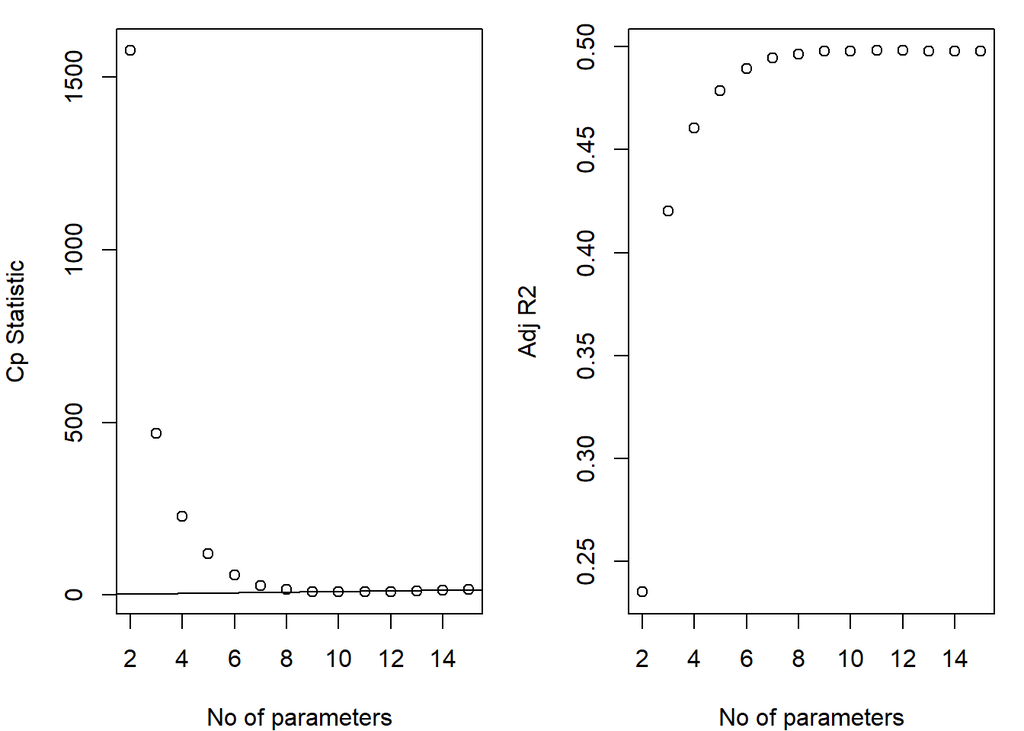

```r
# Summary of models for each size (one model per size)
rs = regsubsets(target_death_rate~., data=tidy_data, nvmax = NULL) %>% summary()

# Plots of Cp and Adj-R2 as functions of parameters
par(mar=c(4,4,1,1))
par(mfrow=c(1,2))

plot(2:15, rs$cp, xlab="No of parameters", ylab="Cp Statistic")
abline(0,1)

plot(2:15, rs$adjr2, xlab="No of parameters", ylab="Adj R2")
```

```r
# look at other criteria

best <- function(model, ...)
{
  subsets <- regsubsets(formula(model), model.frame(model), nvmax = NULL, ...)
  subsets <- with(summary(subsets),
                  cbind(p = as.numeric(rownames(which)), which, rss, rsq, adjr2, cp, bic))

  return(subsets)
}
```

models with good performance in criteria:

model_1:(parameter = 9) region + pct_bach_deg25_over + percent_married +incidence_rate + med_income + pct_unemployed16_over + birth_rate

model_2: (parameter = 10) pop_est2015 + model_1

model_1 is the best model using automatic procedures. Also, considering the principle of parsimony, we choose to pick model_1 as our final model and its information is displayed below.

```r
best_fit = lm(target_death_rate ~ region + pct_bach_deg25_over + percent_married +incidence_rate + med_income + pct_unemployed16_over + birth_rate, data = tidy_data)

summary(best_fit)%>%
        broom::tidy() %>%
        knitr::kable(digits = 3) %>%
        kableExtra::kable_styling(full_width = T, position = "left")
```

| term | estimate | std.error | statistic | p.value |
| --- | --- | --- | --- | --- |
| (Intercept) | 115.897 | 5.572 | 20.800 | 0.000 |
| regionMidwest | 9.410 | 1.219 | 7.722 | 0.000 |
| regionNortheast | 2.089 | 1.760 | 1.187 | 0.235 |
| regionSouth | 14.842 | 1.175 | 12.630 | 0.000 |
| pct_bach_deg25_over | -1.570 | 0.100 | -15.636 | 0.000 |
| percent_married | -0.259 | 0.068 | -3.837 | 0.000 |
| incidence_rate | 0.201 | 0.007 | 29.047 | 0.000 |
| med_income | 0.000 | 0.000 | -3.700 | 0.000 |
| pct_unemployed16_over | 1.041 | 0.140 | 7.443 | 0.000 |
| birth_rate | -0.560 | 0.186 | -3.002 | 0.003 |